# Motus R Package Review

In the next couple of months we will be releasing a basic R-package that will allow users to access their data directly from the Motus database. We plan to improve this package over time to include tools to manage, explore and analyze detection data. To ensure that the R package is tailored for the needs of Motus collaborators, please take some time to review some of the current functions.

# Load R Packages

First, we load some packages. If you do not have these packages installed, you need to first install them using > install.packages(“dplyr”).

```r
require(dplyr)
require(ggplot2)
require(ggmap)
require(RgoogleMaps)
require(lubridate)
require(sensorgnome)
require(geosphere)
require(knitr)
require(pander)
require(forcats)
require(data.table)
```

Then, we’ll manually set system time to UTC

```r
Sys.setenv(TZ='GMT')
```

# Getting Data

```r
## read in detection data
tags <- read.csv("./sample_data.csv")
tags <- rename(tags, port = ant)
## read in deployment data
rec <- read.csv("./receiver-deployments.csv")
## read in antenna data
ant <- read.csv("./antenna-deployments.csv")

## merge deployment, antenna, and receiver data
## convert ts and mfgID column type
tags <- full_join(rec, ant) %>% left_join(tags, .)
tags <- mutate(tags,
               mfgID = factor(mfgID),
               ts = as_datetime(ts, tz = "UTC"))

## keep only necessary columns
tags <- select(tags, ts, sig, receiverID, motusRecvID, recvProjectID,
               port, motusTagID, mfgID, dateBin, tagProjectID, gpsLat, gpsLon,
               deploymentName, dtStart, dtEnd, latitude, longitude, antennaType,
               bearing)
```

# Basic Data Manipulations

Add sunrise/sunset times, as well as time to/from sunrise/sunset to detection files

```r
sun <- timeToSunriset(tags, units = "mins")
sun[72:76, c(1, 3, 16, 17, 20:25)]
```

```
##                     ts      receiverID latitude longitude
## 72 2015-09-10 14:58:17 SG-1012BB012075 45.08947 -64.36866
## 73 2015-09-10 14:58:29 SG-1012BB012075 45.08947 -64.36866
## 74 2015-09-10 14:42:38 SG-1614BBBK1603 45.20700 -64.39780
## 75 2015-09-10 14:42:50 SG-1614BBBK1603 45.20700 -64.39780
## 76 2015-09-10 14:43:21 SG-1614BBBK1603 45.20700 -64.39780
##                sunrise              sunset ts_to_set ts_since_set
## 72 2015-09-10 09:49:46 2015-09-10 22:38:25  460.1471     977.9648
## 73 2015-09-10 09:49:46 2015-09-10 22:38:25  459.9471     978.1648
## 74 2015-09-10 09:49:48 2015-09-10 22:38:38  476.0027     962.1028
## 75 2015-09-10 09:49:48 2015-09-10 22:38:38  475.8027     962.3028
## 76 2015-09-10 09:49:48 2015-09-10 22:38:38  475.2860     962.8195
##    ts_to_rise ts_since_rise
## 72   1132.692      308.5031
## 73   1132.492      308.7031
## 74   1148.373      292.8292
## 75   1148.173      293.0292
## 76   1147.656      293.5459
```

Get dataframe of “transitions” - consecutive detections at different sites - for each tagID

```r
transitions <- siteTrans(tags)
transitions[1:3,]
```

```
##   mfgID                ts.x latitude.x longitude.x deploymentName.x
## 1    94 2015-09-08 11:05:55    51.6578    -80.5676       Piskwamish
## 2    94 2015-09-08 12:00:58    51.8231    -80.6912        Longridge
## 3    94 2015-09-08 13:42:34    51.2913    -80.1168        Netitishi
##                  ts.y latitude.y longitude.y deploymentName.y     tot_ts
## 1 2015-09-08 11:27:56    51.8231    -80.6912        Longridge  1321 secs
## 2 2015-09-08 13:34:20    51.2913    -80.1168        Netitishi  5602 secs
## 3 2015-09-09 16:39:58    51.4839    -80.4500      North Bluff 97044 secs
##       dist       rate   bearing rhumbline_bearing
## 1 20276.69 15.3495019 -24.85271          335.1552
## 2 71327.97 12.7325909 145.82288          146.1176
## 3 31577.38  0.3253925 -47.13708          312.8078
```

We are also hoping to add functions for identifying periods of activity, quiescence, or movement, based on signal strength threshholds, and frequency of detections on antennas or stations.

# Data Summaries

Get overall summary of each tag; first and last detection time, first and last detection site, first and last detection location, total time, distance, overall bearing, and average speed (m/s) between first and last detection, and total number of detections

```r
tag_summary <- tagSum(tags)
head(tag_summary)
```

```
##   mfgID            first_ts             last_ts  first_site   last_site
## 1    94 2015-09-08 10:46:12 2016-01-11 22:36:29  Piskwamish     Koffler
## 2   174 2015-08-17 13:46:07 2015-08-17 13:55:10   Netitishi   Netitishi
## 3   180 2015-08-20 18:42:34 2015-08-22 22:19:38 North Bluff North Bluff
## 4   181 2015-08-23 02:28:45 2015-12-07 11:15:02   Netitishi Swallowtail
## 5   378 2015-09-11 15:35:07 2015-10-26 12:41:29 North Bluff        <NA>
## 6   379 2015-09-15 20:13:07 2015-12-07 11:02:19 North Bluff Swallowtail
##   latitude.x longitude.x latitude.y longitude.y        tot_ts      dist
## 1    51.6578    -80.5676    44.0241    -79.5371 10842617 secs  852242.6
## 2    51.2913    -80.1168    51.2913    -80.1168      543 secs       0.0
## 3    51.4839    -80.4500    51.4839    -80.4500   185824 secs       0.0
## 4    51.2913    -80.1168    44.7650    -66.7366  9189977 secs 1230823.6
## 5    51.4839    -80.4500         NA          NA  3877582 secs        NA
## 6    51.4839    -80.4500    44.7650    -66.7366  7138152 secs 1261731.1
##         rate   bearing num_det
## 1 0.07860119  174.4205    1116
## 2 0.00000000 -180.0000     141
## 3 0.00000000 -180.0000      73
## 4 0.13393109  120.8921    1151
## 5         NA        NA     656
## 6 0.17675879  120.9254      88
```

Summarise first and last detections of all tags by site

```r
tag_site_summary <- tagSumSite(tags, units = "mins")
head(tag_site_summary)
```

```
##   mfgID deploymentName            first_ts             last_ts
## 1    94        Borgles 2015-09-10 16:19:40 2015-09-10 16:29:31
## 2    94      COBEQUID3 2015-09-10 15:31:30 2015-09-10 15:45:31
## 3    94 D'Estimauville 2015-09-10 09:03:12 2015-09-10 09:04:44
## 4    94       Fundy NP 2015-09-10 13:52:38 2015-09-10 13:53:27
## 5    94        Huggins 2015-09-10 14:50:21 2015-09-10 14:58:29
## 6    94   JONSONSMILLS 2015-09-10 14:02:27 2015-09-10 14:10:47
##            tot_ts num_det
## 1  9.8500000 mins      70
## 2 14.0166667 mins      87
## 3  1.5333333 mins       5
## 4  0.8166667 mins       8
## 5  8.1333333 mins      73
## 6  8.3333333 mins      24
```

Summarise the detections of all tags by site for each day; first and last detection, total detection time, total number of tags, total number of detections)

```r
daily_site_summary <- siteSumDaily(tags, units = "mins")
head(daily_site_summary)
```

```
##          deploymentName       date            first_ts             last_ts
## 1 Assateague State Park 2015-09-13 2015-09-13 10:12:51 2015-09-13 10:14:41
## 2           Bombay Hook 2015-09-12 2015-09-12 14:45:08 2015-09-12 14:52:20
## 3               Borgles 2015-09-10 2015-09-10 16:19:40 2015-09-10 16:29:31
## 4                  BULL 2015-09-19 2015-09-19 05:59:35 2015-09-19 06:08:31
## 5                  BULL 2015-10-26 2015-10-26 21:49:58 2015-10-26 21:50:37
## 6             COBEQUID3 2015-09-10 2015-09-10 15:31:30 2015-09-10 15:45:31
##           tot_ts num_tags num_det
## 1  1.833333 mins        1       6
## 2  7.200000 mins        1     120
## 3  9.850000 mins        1      70
## 4  8.933333 mins        1      62
## 5  0.650000 mins        1       5
## 6 14.016667 mins        1      87
```

Summarize and plot detections of all tags by site, can specify units that total time is displayed in

```r
site_summary <- siteSum(tags, units = "mins")
```

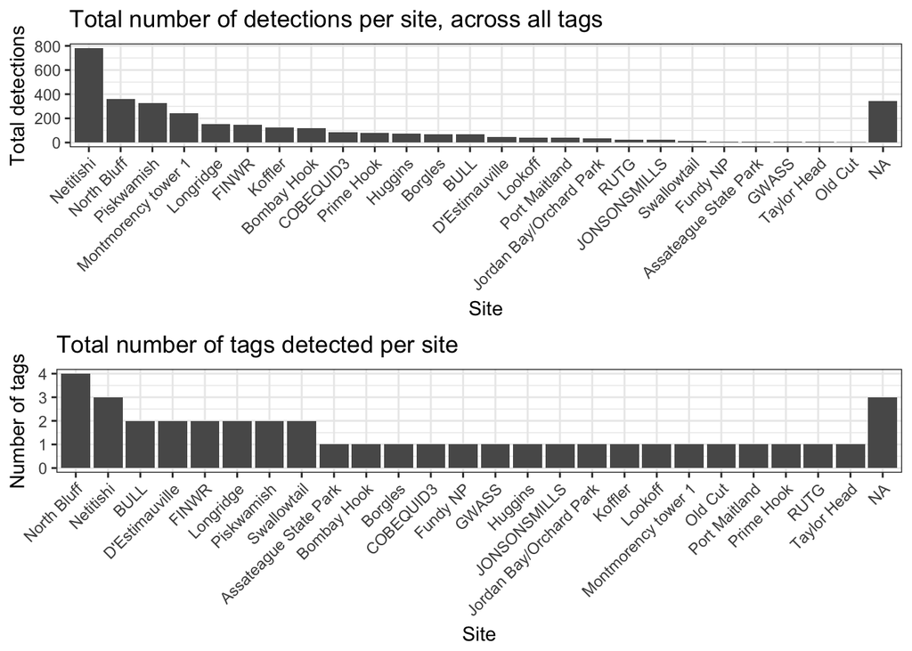

```r
head(site_summary)
```

```
##          deploymentName            first_ts             last_ts
## 1 Assateague State Park 2015-09-13 10:12:51 2015-09-13 10:14:41
## 2           Bombay Hook 2015-09-12 14:45:08 2015-09-12 14:52:20
## 3               Borgles 2015-09-10 16:19:40 2015-09-10 16:29:31
## 4                  BULL 2015-09-19 05:59:35 2015-10-26 21:50:37
## 5             COBEQUID3 2015-09-10 15:31:30 2015-09-10 15:45:31
## 6        D'Estimauville 2015-09-02 06:44:20 2015-09-10 09:04:44
##              tot_ts num.tags num.det
## 1     1.833333 mins        1       6
## 2     7.200000 mins        1     120
## 3     9.850000 mins        1      70
## 4 54231.033333 mins        2      67
## 5    14.016667 mins        1      87
## 6 11660.400000 mins        2      45
```

Get a dataframe consisting of simultaneous detections at multiple sites

```r
sim <- simSiteDet(tags)
sim[1:5, c("mfgID", "ts", "sig", "receiverID", "port", "bearing", "gpsLat", "gpsLon")]
```

```
##   mfgID                  ts      sig      receiverID port bearing   gpsLat
## 1    94 2015-09-10 14:46:42 -68.1508 SG-1012BB012075    5      NA 45.08945
## 2    94 2015-09-10 14:46:42 -70.0632 SG-1614BBBK1603    3      50 45.20698
## 3    94 2015-09-10 14:46:42 -67.4204 SG-1614BBBK1603    1     290 45.20698
## 4    94 2015-09-10 14:46:54 -67.5630 SG-1012BB012075    5      NA 45.08945
## 5    94 2015-09-10 14:46:54 -69.6060 SG-1614BBBK1603    1     290 45.20698
##      gpsLon
## 1 -64.36867
## 2 -64.39780
## 3 -64.39780
## 4 -64.36867
## 5 -64.39780
```

# Data Visualizations

## Plot Detection data

Plot all tags by latitude, you can adjust the number of tags visible in each facet by adjusting “tagsPerPanel”

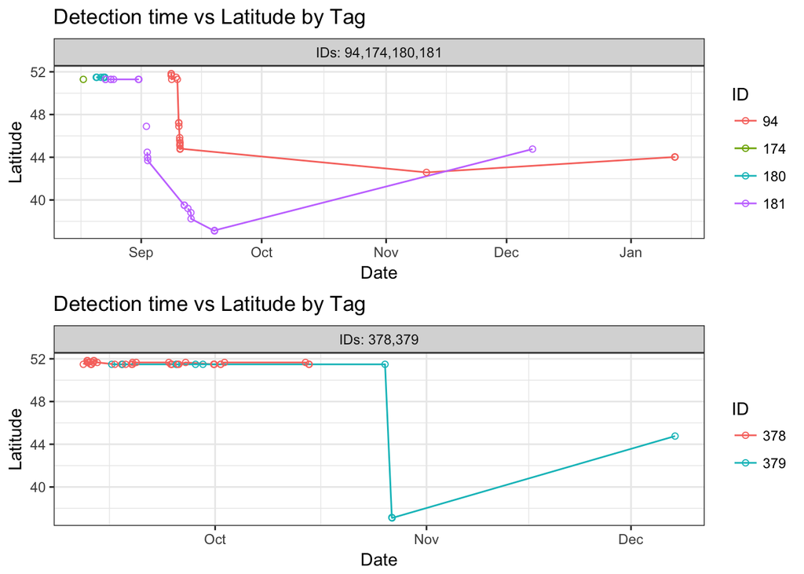

```r
plotAllTagsLat(tags, tagsPerPanel = 4)
```

Plot all detections of a specified tag by site

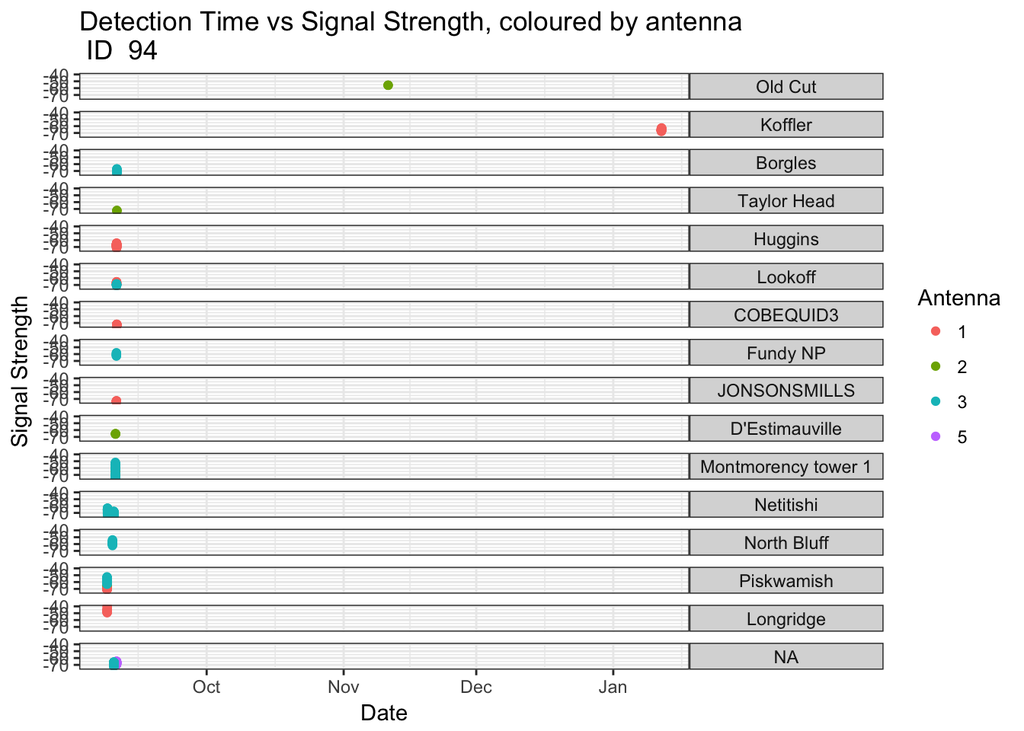

```r
plotTagSig(tags, tag = 94)
```

Plot all tags by site, you can adjust the number of tags visible in each facet by adjusting “tagsPerPanel”

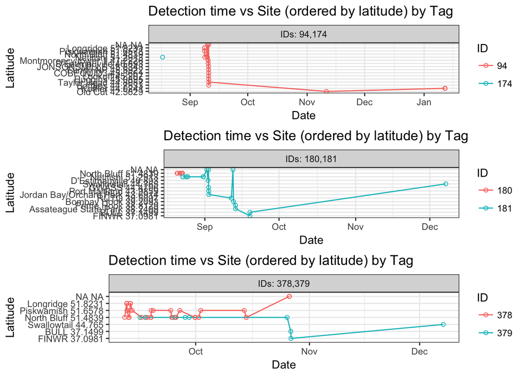

```r
plotAllTagsSite(tags, tagsPerPanel = 2)
```

Plot all detections at a specified site

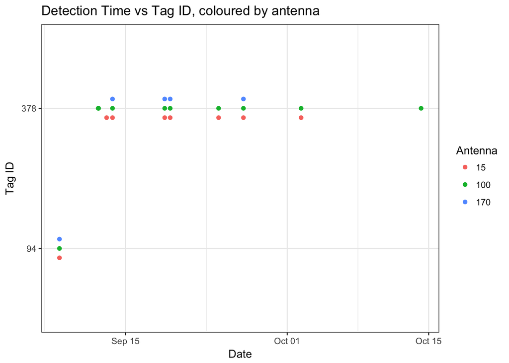

```r
plotSite(tags, depName = "Piskwamish")
```

Plot signal strength of all tags at a specified site

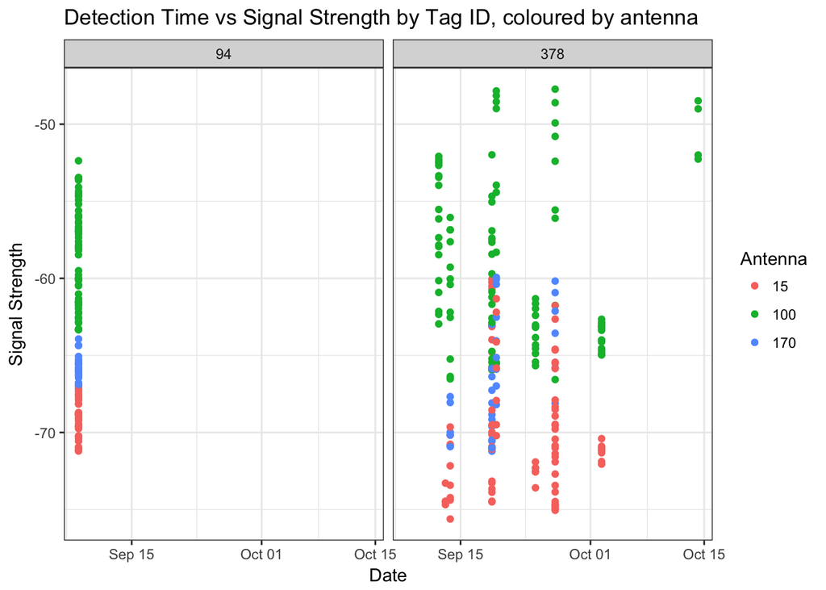

```r
plotSiteSig(tags, depName = "Piskwamish")
```

## Plot site detection summaries

Plot the total number of detections across all tags, and the total number of tag detected per day for a specified site.

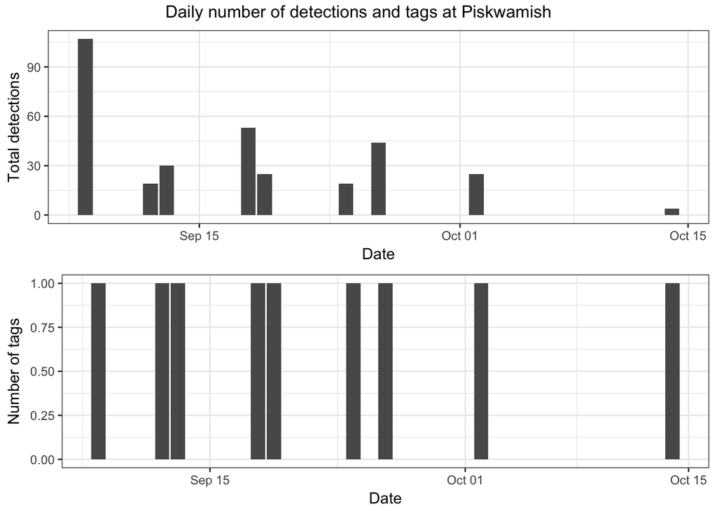

```r
plotDailySiteSum(tags, Site = "Piskwamish")
```

## Plot Route Maps

Plot route estimates coloured by ID, with all sites. You can specify maptype (terrain, satellite, roadmap, hybrid), map center (latCentre/lonCentre), zoom, and the time frame for active receivers to be displayed.

[figure not shown]

```r
plotRouteMap(site_data = rec, detection_data = tags, maptype = "terrain",
latCentre = 44, lonCentre = -70, zoom = 5, startTime = "2016-01-01", endTime = "2016-12-31")
```

We are also hoping to add functions for station operation plots (active/inactive periods for stations, antenna, and gps), as well as maps of receivers active during a specified time period including antenna directions and range estimates.

After reviewing these functions, are there any other tools that you would like to see included? If already have scripts for other tools and would like to contribute to the R package, please let us know at motus@birdscanada.org